# Spatial Queries and Joins

```r
library(sf)
library(dplyr)
library(units)
library(tibble)
library(tmap)
```

# Example: Find POIs that Intersect the Merced Watershed

Start by importing the watersheds, grouping by HU (larger watershed units):

```r
## Import the watersheds, grouping by HUNAME
gpkg_watershd_fn <- "./data/yose_watersheds.gpkg"
yose_hu_watersheds <- st_read(gpkg_watershd_fn, layer="calw221") %>%
  group_by(HU) %>%
  summarise(HUNAME = first(HUNAME), NUM_WATERSHEDS = n())
```

Pull out just the Merced watershed and plot it:

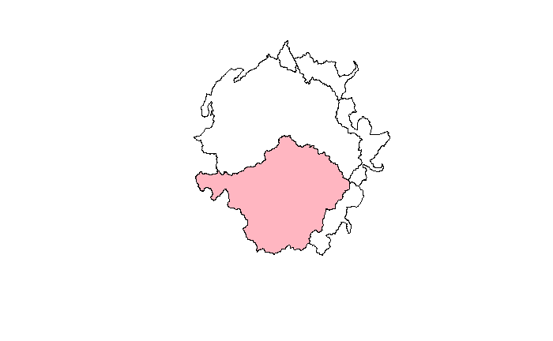

```r
## Filter out just the Merced River watershid
merced_watershed <- yose_hu_watersheds %>% dplyr::filter(HUNAME == "MERCED RIVER")

## Plot boundaries
plot(yose_hu_watersheds %>% st_geometry())
plot(merced_watershed %>% st_geometry(), add=TRUE, col="lightpink")
```

Next import the points of interest:

```r
## Import points of interest
yose_poi <- st_read(dsn="./data", layer="yose_poi")
```

Apply the intersects test:

```r
merced_poi <- yose_poi %>% st_intersects(merced_watershed)
```

```
Error in st_geos_binop("intersects", x, y, sparse = sparse, prepared = prepared,  :
  st_crs(x) == st_crs(y) is not TRUE
```

ERROR message! Spatial querying requires features to be in the same crs!

Project the HU watershed layer (which is in Albers) to match the points of interest (which are UTM):

```r
yose_hu_utm <- yose_hu_watersheds %>% st_transform(st_crs(yose_poi))
merced_hu_utm <- yose_hu_utm %>% dplyr::filter(HUNAME == "MERCED RIVER")
```

Try the intersects test again:

```r
yose_poi_merced_yn <- yose_poi %>% st_intersects(merced_hu_utm, sparse=FALSE)
head(yose_poi_merced_yn)
```

```
     [,1]
[1,] TRUE
[2,] TRUE
[3,] TRUE
[4,] TRUE
[5,] TRUE
[6,] TRUE
```

## YOUR TURN!

How many points intersect the Merced Rivershed watershed polygon?

Plot the results to make sure:

```r
## Extract the points that intersect the watershed to a new sf object
merced_poi <- yose_poi %>% filter(yose_poi_merced_yn[,1])

## Plot
plot(yose_hu_utm  %>% st_geometry(), border="gray70")
plot(merced_hu_utm %>% st_geometry(), add=TRUE, col="lightpink")
```

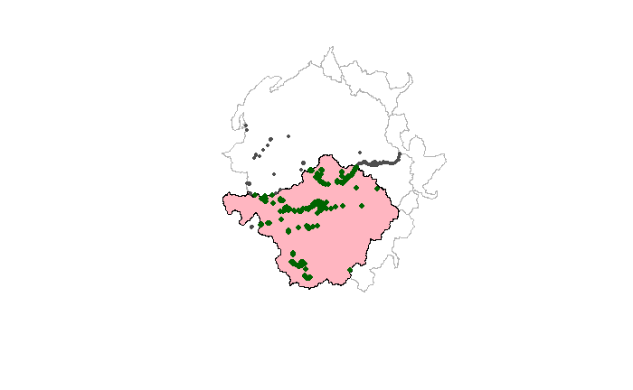

```r
plot(yose_poi %>% st_geometry(), col="gray30", pch=16, cex=0.5, add=TRUE)
plot(merced_poi %>% st_geometry(), col="darkgreen", pch=16, cex=0.8, add=TRUE)
```

# Example: Generating Random Points inside an Irregular Polygon

First, we import the boundary and generate 1500 points within the bounding box:

```r
## Import the Yosemite border
yose_bnd_ll <- st_read(dsn="./data", layer="yose_boundary")
```

Next, generate uniformly distributed random numbers between the x and y ranges

```r
## Generate uniformly distributed random numbers between the x and y ranges
n <- 500
yose_ext <- st_bbox(yose_bnd_ll)
xs <- runif(n * 3, min = yose_ext[1], max = yose_ext[3])
ys <- runif(n * 3, min = yose_ext[2], max = yose_ext[4])
```

Create a sf object from the random points

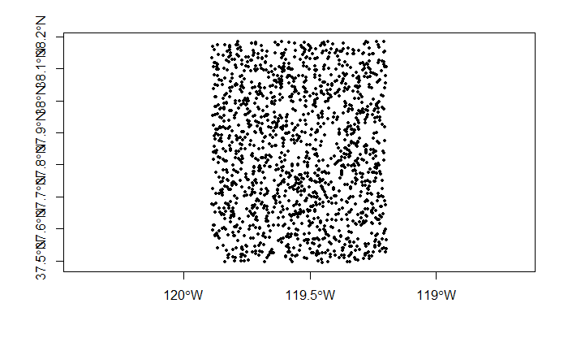

```r
rand_pts <- st_as_sf(data.frame(lon = xs, lat = ys),
                     coords = c("lon", "lat"),
                     crs=st_crs(yose_bnd_ll))

## Plot
plot(rand_pts, axes=T, pch=16, cex=0.5)
```

Next, test which points fall within the park boundary, and save those to a new object.

```r
## Test which points are within the YNP boundary
in_yose_mat <- st_within(rand_pts, yose_bnd_ll, sparse = FALSE)
```

```
although coordinates are longitude/latitude, st_within assumes that they are planar
```

```r
head(in_yose_mat)
```

```
      [,1]
[1,]  TRUE
[2,]  TRUE
[3,]  TRUE
[4,]  TRUE
[5,]  TRUE
[6,] FALSE
```

```r
## Save those in the park to a new sf object
pts_in_park <- rand_pts %>% filter(in_yose_mat[,1])
nrow(pts_in_park)
```

```
[1] 983
```

Plot the results:

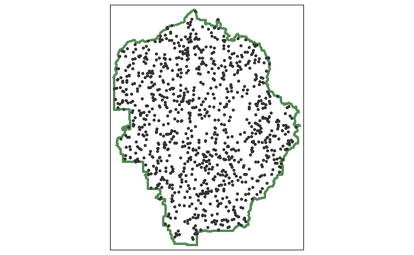

Lastly, all we need is 500 points so take a random sample:

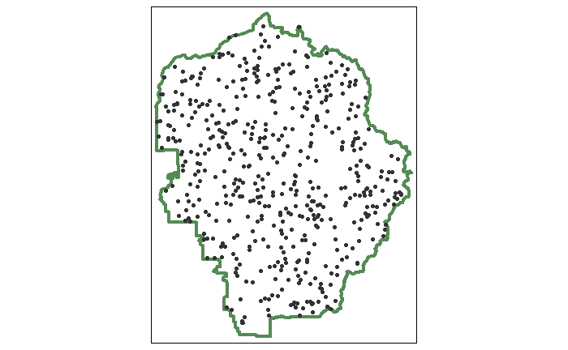

```r
## Take a random sample of the points
pts_in_park_500 <- pts_in_park %>% sample_n(n)

## Plot
tm_shape(yose_bnd_ll) + tm_borders(col="palegreen4", lwd = 4) +
  tm_shape(pts_in_park_500) + tm_dots(size = 0.1, col = "gray20")
```

# Example: Find the closest trail to each campground

```r
## FIND THE CLOSEST TRAIL TO EACH CAMPGROUND

## Define a convenience variable for UTM Zone 11
epsg_utm11n_nad83 <- 26911

## Import the campgrounds
yose_campgrnds_utm <- st_read(dsn="./data", layer="yose_poi") %>%
  dplyr::filter(POITYPE == 'Campground') %>%
  dplyr::select(POINAME) %>%
  st_transform(epsg_utm11n_nad83)
## Import the trails
gdb_fn <- "./data/yose_trails.gdb"
file.exists(gdb_fn)
```

```
[1] TRUE
```

```r
yose_trails_utm <- st_read(gdb_fn, layer="Trails") %>%
  st_transform(epsg_utm11n_nad83)
## Load the nngeo package
library(nngeo)

## Run the st_nn, return results as list
closest_trail_lst <- st_nn(yose_campgrnds_utm, yose_trails_utm, sparse = TRUE, progress = FALSE)
```

```
lines or polygons
```

```r
closest_trail_idx <- unlist(closest_trail_lst)
closest_trail_idx
```

```
 [1] 610 117 275 467 504 961 237 432 343 563 541 603 566 927  72
```

Plot the results:

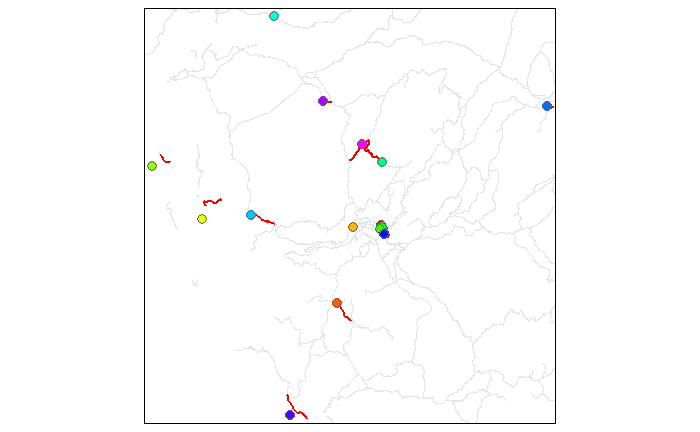

```r
## Plot results
rainbow_cols <- rainbow(nrow(yose_campgrnds_utm), end=5/6)
tm_shape(yose_trails_utm, bbox=yose_campgrnds_utm) +
  tm_lines(col="gray90") +
  tm_shape(yose_trails_utm %>% slice(closest_trail_idx)) +
  tm_lines(col="red", lwd=2) +
  tm_shape(yose_campgrnds_utm) +
  tm_symbols(col="POINAME", palette = rainbow_cols, size=0.5) +
  tm_layout(legend.show = FALSE)
```